# Calibrating the ‘ageified’ model

Irena Papst

Last updated: 12 Apr 2021 at 22:21

```r
knitr::opts_chunk$set(fig.height = 4,
                      fig.width = 9)

devtools::load_all()
```

```
## Loading McMasterPandemic
```

```r
library(tidyverse)
```

```r
library(cowplot)
```

We want to be able to calibrate $\beta$ in the age-structured model, but trying to fit a $\beta$ value for each age group may be too difficult (or impossible). Let’s see how far we can get with $\beta$ calibrated to the whole population.

# Simple calibration for constant $\beta$

## Idea

We can break $\beta_0$ down into two components: transmissiblity, $\tau$ (proportion of contacts between $S$ and $I$ that lead to transmission) and the average contact rate $\langle c \rangle$ (contacts/day):

$$\beta_0 = \tau \langle c \rangle.$$

In the age-structured model, if we assume transmissibility is constant across age groups, we have

$$(\beta_0)_i = \tau c_i$$

for each age group $i$. Instead of calibrating each $(\beta_0)_i$, let’s try to:

1. estimate $\beta_0$ for the entire population via calibration;
2. calculate $\tau$ using the estimated $\beta_0$ and the calculated $\langle c \rangle$ from the assumed $c_i$ in the age-structured model, yielding $(\beta_0)_i$ for each age group.

Here’s a function that does this lazy calibration:

```r
#' Calibrate age-specific transmission params using population-level beta0 and assumed contact structure
#'
#' @param age_params parameters that have been initialized using `expand_params_age()` with a specified age-specific contact rate
#' @param base_beta0 beta0 calibrated from base (non-ageified) simulation
#'
#' @return an object of class `params_pansim`
#' @export
#'
#' @examples
#' base_params <- update(read_params("PHAC_testify.csv"), testing_intensity = 0, beta0 = 2)
#' age_params <- expand_params_age(base_params, transmissibility = 1, contact_rate_age = rep(4, length(age_cat)))
#' calibrate_transmission(age_params)
calibrate_transmission <- function(age_params, base_beta0){
  ## calculate average age-specific contact rate
  avg_contact_rate_age <- sum(age_params[["N"]]*age_params[["contact_rate_age"]])/sum(age_params[["N"]])

  ## calculate transmissibility implied by average contact rate
  transmissibility <- base_beta0/avg_contact_rate_age
  print(paste0("calculated transmissibility: ", transmissibility))

  ## update beta0 (and transmissibility in age_params)
  ## based on assumed contact_rate_age and implied transmissibility
  age_params[["beta0"]] <- transmissibility*age_params[["contact_rate_age"]]
  age_params[["transmissibility"]] <- transmissibility

  return(age_params)
}
```

Here’s a function that computes both the base sim, as well as the ageified sim (with lazy calibration):

```r
#' Compare ageified simulation to base, using simple calibration trick
#'
#' @param age_cat age categories
#' @param base_beta0 beta0 to use in base simulation
#' @param Nvec population distribution
#' @param pmat contact probability matrix
#' @param contact_rate_age age-specific contact rates
#' @inheritParams run_sim
#'
#' @return
#' @export
compare_age_to_base <- function(age_cat,
                                base_beta0,
                                Nvec,
                                pmat = NULL,
                                contact_rate_age,
                                start_date = "2020-03-01",
                                end_date = "2020-08-01",
                                params_timevar = NULL){

  ## set up base (non-ageified) params and state
  base_params <- update(read_params("PHAC_testify.csv")
                        , N = sum(Nvec)
                        , testing_intensity = 0
                        , beta0 = base_beta0
                        )
  base_state <- make_state(N = base_params[["N"]],
                           E0 = length(age_cat))

  ## run base simulation
  res_base <- run_sim(base_params, base_state,
                      start_date = start_date,
                      end_date = end_date,
                      params_timevar = params_timevar,
                      condense = FALSE)

  ## set up ageified parameters
  ## (this will use assume beta0 as in the base simulation)
  age_params <- expand_params_age(
    params = base_params,
    age_cat = age_cat,
    Nvec = Nvec,
    pmat = pmat,
    transmissibility = 1, ## dummy value, will get updated
    contact_rate_age = contact_rate_age
  )

  ## perform lazy calibration (update transmissibility based on base_beta0
  ## and contact_rate_age)
  age_params <- calibrate_transmission(age_params, base_beta0)

  ## set up age-structured state
  age_state <- expand_state_age(
    base_state,
    age_cat = age_cat,
    Nvec = age_params[["N"]]
  )

  ## age-structured sim with beta0 vec and transmissibility
  ## "inferred" from base sim
  res_age <- run_sim(age_params, age_state,
                     start_date = start_date,
                     end_date = end_date,
                     params_timevar = params_timevar,
                     condense = FALSE)

  ## aggregate over ages
  res_age_cond <- condense_age(res_age %>% select(!starts_with("foi")))
  attr(res_age_cond, "row.names") <- as.character(attr(res_age_cond, "row.names"))

  ## check sim results are equal
  print("comparing base and ageified simulation results... equal?")
  print(all.equal(res_age_cond,
                   res_base %>% select(-foi)))

  ## plot sim results
  p <- (bind_rows(
    pivot_longer((res_base
      %>% select(-foi)
      %>% mutate(model = "base")),
    cols = -c(date, model),
    names_to = "var"),
    pivot_longer((condense_age(res_age %>% select(!starts_with("foi")))
      %>% mutate(model = "age-structured")),
    cols = -c(date, model),
    names_to = "var"))
    %>% mutate(var = as_factor(var))
    %>% ggplot(aes(x = date, y = value, color = model))
    + geom_line()
    + facet_wrap(vars(var), scales = "free_y")
    + scale_x_date(date_breaks = "1 month",
                   date_labels = "%b")
  )

  print(p)

}
```

## Demo with a uniform population, uniform contact strucutre

This should work perfectly…

```r
## set up age categories
age_cat <- mk_agecats(0, 80, da = 30)
n <- length(age_cat)
Ni <- 1e6
Nvec <- rep(Ni, n)
base_beta0 <- 2

compare_age_to_base(
  age_cat = age_cat,
  base_beta0 = base_beta0,
  Nvec = Nvec,
  contact_rate_age = rep(4, length(age_cat))
)
```

```
## [1] "calculated transmissibility: 0.5"
## [1] "comparing base and ageified simulation results... equal?"
## [1] TRUE
```

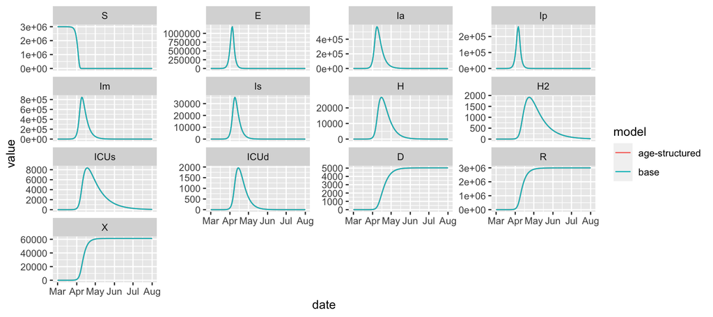

Not shocking; if this wasn’t a perfect match, it would be because of a bug.

## Uniform population, non-uniform contact structure

```r
Nvec <- rep(5e6, 3)
true_beta0 <- c(2, 3, 3/2)

base_beta0 <- sum(Nvec*true_beta0)/sum(Nvec)
true_transmissibility <- 0.5
contact_rate_age <- true_beta0/true_transmissibility

## initialize contact structure
pmat <- matrix(c(4/10, 4/30, 8/15,
                 2/10, 23/30, 3/15,
                 4/10, 1/10, 4/15),
               nrow = 3,
               dimnames = list(age_cat, age_cat))

compare_age_to_base(
  age_cat = age_cat,
  base_beta0 = base_beta0,
  Nvec = Nvec,
  pmat = pmat,
  contact_rate_age = contact_rate_age
)
```

```
## [1] "calculated transmissibility: 0.5"
## [1] "comparing base and ageified simulation results... equal?"
##  [1] "Component \"S\": Mean relative difference: 0.05118988"
##  [2] "Component \"E\": Mean relative difference: 0.3979106"
##  [3] "Component \"Ia\": Mean relative difference: 0.224402"
##  [4] "Component \"Ip\": Mean relative difference: 0.3908463"
##  [5] "Component \"Im\": Mean relative difference: 0.2236225"
##  [6] "Component \"Is\": Mean relative difference: 0.2468966"
##  [7] "Component \"H\": Mean relative difference: 0.1400973"
##  [8] "Component \"H2\": Mean relative difference: 0.08530774"
##  [9] "Component \"ICUs\": Mean relative difference: 0.09306193"
## [10] "Component \"ICUd\": Mean relative difference: 0.1563403"
## [11] "Component \"D\": Mean relative difference: 0.01541087"
## [12] "Component \"R\": Mean relative difference: 0.01444124"
## [13] "Component \"X\": Mean relative difference: 0.01429806"
```

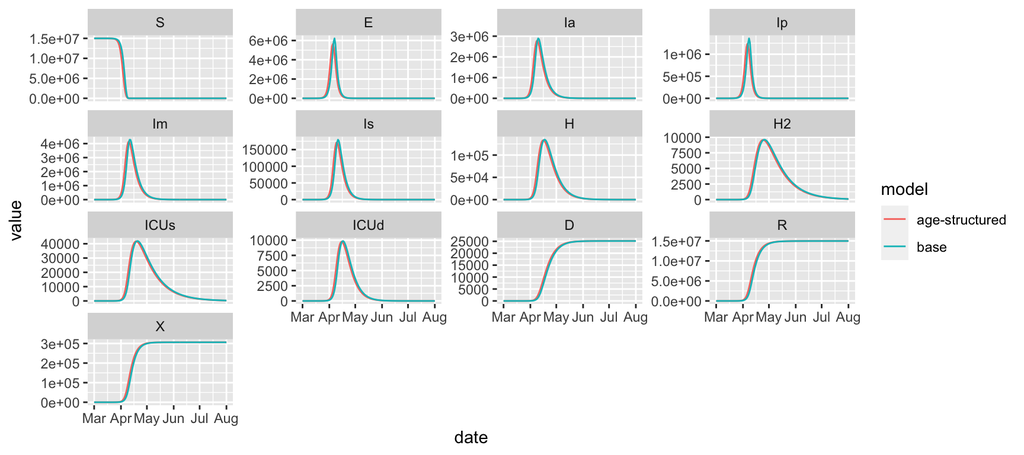

Not a perfect match, but it looks like there’s pretty good agreement…

## Demo with a non-uniform population, non-uniform contact structure

```r
## rescale to a non-uniform population while still maintaining balance
total_contacts <- true_beta0*Nvec
true_beta0 <- 1:3
Nvec <- total_contacts/true_beta0

## check balance
# isSymmetric((Nvec*true_beta0)*pmat)

base_beta0 <- sum(Nvec*true_beta0)/sum(Nvec)
true_transmissibility <- 0.5
contact_rate_age <- true_beta0/true_transmissibility

compare_age_to_base(
  age_cat = age_cat,
  base_beta0 = base_beta0,
  Nvec = Nvec,
  pmat = pmat,
  contact_rate_age = contact_rate_age
)
```

```
## [1] "calculated transmissibility: 0.5"
## [1] "comparing base and ageified simulation results... equal?"
##  [1] "Component \"S\": Mean relative difference: 0.06371058"
##  [2] "Component \"E\": Mean relative difference: 0.5179538"
##  [3] "Component \"Ia\": Mean relative difference: 0.3143379"
##  [4] "Component \"Ip\": Mean relative difference: 0.5125095"
##  [5] "Component \"Im\": Mean relative difference: 0.3133846"
##  [6] "Component \"Is\": Mean relative difference: 0.3435535"
##  [7] "Component \"H\": Mean relative difference: 0.2026077"
##  [8] "Component \"H2\": Mean relative difference: 0.1245991"
##  [9] "Component \"ICUs\": Mean relative difference: 0.1358177"
## [10] "Component \"ICUd\": Mean relative difference: 0.2254467"
## [11] "Component \"D\": Mean relative difference: 0.02401718"
## [12] "Component \"R\": Mean relative difference: 0.02242644"
## [13] "Component \"X\": Mean relative difference: 0.02224959"
```

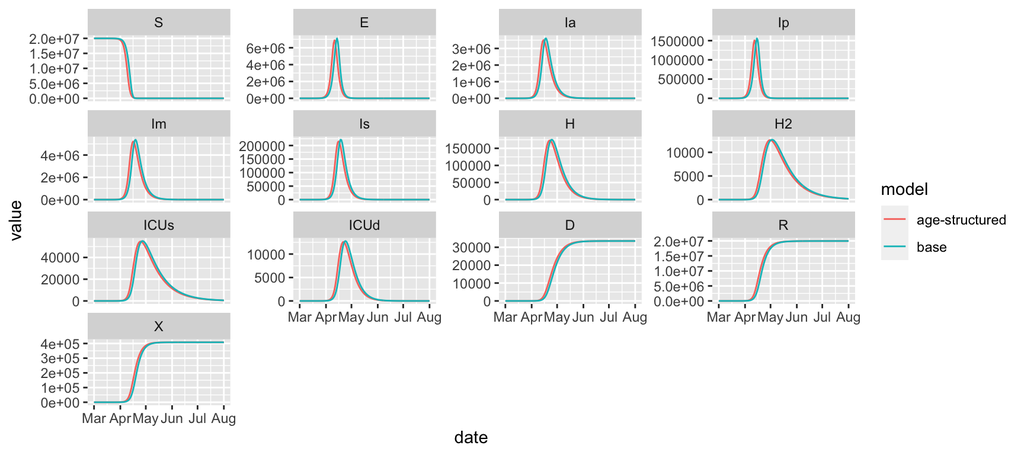

Again, not terrible… not sure how sensitive the match is to the population distribution, relative magnitudes of the true $(\beta_0)_i$, and the assumed contact probability matrix.

# Simple calibration with time-varying $\beta$

Let’s just go all-in with age-based heterogeneity in $\beta_0$, contact probabilities between ages, and the population distribution, plus a time-varying $\beta$:

```r
time_pars <- data.frame(Date=c("2020-04-02", "2020-05-01"),
                      Symbol=c("beta0", "beta0"),
                      Relative_value=c(0.1, 1))

compare_age_to_base(
  age_cat = age_cat,
  base_beta0 = base_beta0,
  Nvec = Nvec,
  pmat = pmat,
  contact_rate_age = contact_rate_age,
  params_timevar = time_pars
)
```

```
## [1] "calculated transmissibility: 0.5"
## [1] "comparing base and ageified simulation results... equal?"
##  [1] "Attributes: < Component \"row.names\": 121 string mismatches >"
##  [2] "Component \"S\": Mean relative difference: 0.08619015"
##  [3] "Component \"E\": Mean relative difference: 0.5189624"
##  [4] "Component \"Ia\": Mean relative difference: 0.3969773"
##  [5] "Component \"Ip\": Mean relative difference: 0.5145684"
##  [6] "Component \"Im\": Mean relative difference: 0.3955353"
##  [7] "Component \"Is\": Mean relative difference: 0.4165557"
##  [8] "Component \"H\": Mean relative difference: 0.3114266"
##  [9] "Component \"H2\": Mean relative difference: 0.2238465"
## [10] "Component \"ICUs\": Mean relative difference: 0.2381268"
## [11] "Component \"ICUd\": Mean relative difference: 0.3308522"
## [12] "Component \"D\": Mean relative difference: 0.06787966"
## [13] "Component \"R\": Mean relative difference: 0.06222161"
## [14] "Component \"X\": Mean relative difference: 0.06169501"
```

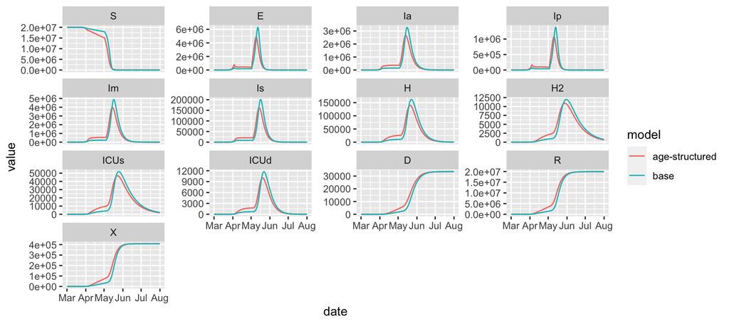

# Calibration using `calibrate()`

Let’s see if we can feed in simulated age-structured observations with constant `beta0` across age groups (+ uniform population size + contact rate) and recover `beta0` via `calibrate()`. We’ll start with the calibration from the getting started vignette:

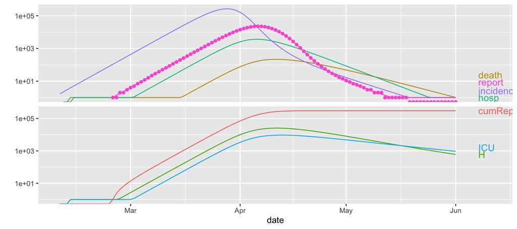

```r
params1 <- read_params("PHAC_testify.csv")
params1 <- update(params1,
                  testing_intensity = 0,
                  N = 3e6)
state1 <- make_state(params=params1)
sdate <- "2020-Feb-10"
edate <- "2020-Jun-1"

## add observational noise
set.seed(101)
params1obs <- update(params1, obs_disp=200)
res1obs <- run_sim(params1obs, state1, start_date=sdate, end_date=edate,
                   stoch=c(obs=FALSE, proc=FALSE),
                   condense_args = c(add_report = TRUE))

## set up simulated report data
report_data <- (res1obs
    %>% mutate(value=round(report), var="report")
    %>% select(date, value, var)
    %>% na.omit() ## removing first 15 values, which are NA!
)

## beta0 is the only parameter we're going to optimize:
opt_pars <- list(params = c(beta0 = 0.1)) ## fit beta0 based on the report data:
fitted.mod <- calibrate(
    data = report_data
  , start_date = sdate
    ## skip breaks that are present by default:
  , time_args = list(break_dates = NULL)
  , base_params = params1obs
  , opt_pars = opt_pars
##, debug_plot = TRUE # instructive plotting during optimization
)
## plot the resulting fit
plot(fitted.mod, data=report_data)
```

```r
## compare original beta0 to fit value
print("preset beta0:")
```

```
## [1] "preset beta0:"
```

```r
print(params1[["beta0"]])
```

```
## [1] 1
```

```r
print("fitted beta0:")
```

```
## [1] "fitted beta0:"
```

```r
print(coef(fitted.mod$mle2)[[1]])
```

```
## [1] 1
```

Cool, so this base example is working. Let’s do the smallest ageify expansion upon this working example by implementing uniform age-structure (both in transmission, contacts rate, and population distribution):

```r
## ageify the parameters
age_cat <- mk_agecats(0, 80, da = 30)
n <- length(age_cat)

params1_age <- expand_params_age(params1, age_cat = age_cat)
state1_age <- expand_state_age(state1, age_cat = age_cat)
sdate <- "2020-Feb-10"
edate <- "2020-Jun-1"

## add observational noise
set.seed(101)
params1obs_age <- update(params1_age, obs_disp=200)
res1obs <- run_sim(params1obs_age, state1_age, start_date=sdate, end_date=edate,
                   stoch=c(obs=FALSE, proc=FALSE),
                   condense = TRUE, ## this is the default, but specifying it here because i just realized i need it to generate the reports col
                   condense_args = list(keep_all = TRUE,
                                        add_report = TRUE) ## this will also keep the original variables in the df, which i need for later to stratify by age
                   )
# res1obs <- run_sim(params1obs_age, state1_age, start_date=sdate, end_date=edate,
#                    stoch=c(obs=FALSE, proc=FALSE),
#                    condense = FALSE)

## set up simulated report data
## FIXME: FIX THIS NEXT SOMETHING IS BROKEN HERE WITH AGE-SPECIFIC REPORTS
report_data <- (res1obs
    %>% mutate(across(starts_with("report"), ~ round(.x), .names = {.col}))
    %>% select(date, starts_with("report"), var)
    %>% na.omit() ## removing first 15 values, which are NA!
)

## beta0 is the only parameter we're going to optimize:
opt_pars <- list(params = c(beta0 = 0.1)) ## fit beta0 based on the report data:
fitted.mod <- calibrate(
    data = report_data
  , start_date = sdate
    ## skip breaks that are present by default:
  , time_args = list(break_dates = NULL)
  , base_params = params1obs
  , opt_pars = opt_pars
##, debug_plot = TRUE # instructive plotting during optimization
)

## plot the resulting fit
plot(fitted.mod, data=report_data)

## compare original beta0 to fit value
print("preset beta0:")
print(params1[["beta0"]])
print("fitted beta0:")
print(coef(fitted.mod$mle2)[[1]])
```

```r
Nvec <- rep(5e6, 3)
true_beta0 <- c(2, 3, 3/2)

base_beta0 <- sum(Nvec*true_beta0)/sum(Nvec)
true_transmissibility <- 0.5
contact_rate_age <- true_beta0/true_transmissibility

## initialize contact structure
pmat <- matrix(c(4/10, 4/30, 8/15,
                 2/10, 23/30, 3/15,
                 4/10, 1/10, 4/15),
               nrow = 3,
               dimnames = list(age_cat, age_cat))

compare_age_to_base(
  age_cat = age_cat,
  base_beta0 = base_beta0,
  Nvec = Nvec,
  pmat = pmat,
  contact_rate_age = contact_rate_age
)
```